## `patchwork`

`ggplot2` 패키지를 사용해 그려진 플롯은 여러개를 동시에 그릴 수 없다. 여러개의 ggplot을 붙여 그리려면 이를 지원하는 특수 패키지인 `patchwork`를 사용해야 한다.

`patchwork`를 사용하려면 먼저 패키지를 설치하고 로딩해야한다.

```r
install.packages('patchwork')
library(patchwork)
```

우선 `ggplot`으로 플롯을 몇개 그린다. (샘플 데이터는 [tidyverse를 사용한 열 선택 방법](https://2stndard.tistory.com/22)에서 사용한 [시도별 행정구별 주요 교육 통계 현황(2010~2020)](https://kess.kedi.re.kr/post/6694057?itemCode=04&menuId=m_02_04_03_01)을 사용한다. 데이터 로딩 방법은 해당 포스트를 참조하라.) 여기서는 초등학교, 중학교, 고등학교의 학급당 학생수에 대한 밀도분포와 각 시도별 학교급별 학급당 학생수를 확인해 볼 수 있는 플롯을 생성하겠다. 이를 위해 초등학교, 중학교, 고등학교 학급당 학생수에 관한 밀도분포 함수 플롯 3종과 초등학교, 중학교, 고등학교의 지역별 학급당 학생수 막대 플롯 3종을 `patchwork`를 사용하여 하나의 플롯으로 구성해본다.

## 학교급별 밀도분포 함수 플롯

학교급별 밀도분포 함수 플롯은 다음과 같이 생성한다.

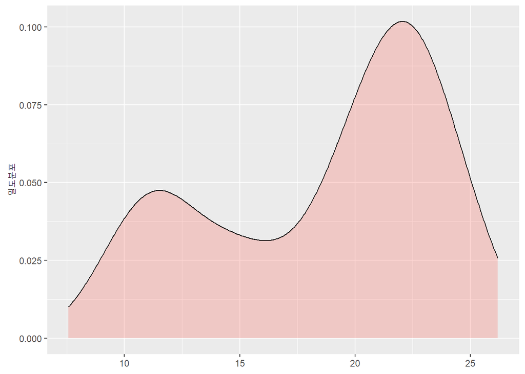

```r
library(tidyverse)
data %>%
  filter(학교급 %in% c('초등학교')) %>%
  mutate(학급당학생수 = 학생수_계_계 / 학급수_계) %>%
  ggplot(aes(x = 학급당학생수, fill = 학교급)) +
  geom_density(alpha = 0.3) +
  labs(y = '밀도분포') +
  theme(legend.position = 'none',
        axis.title.x=element_blank()) -> density_초등학교

density_초등학교
```

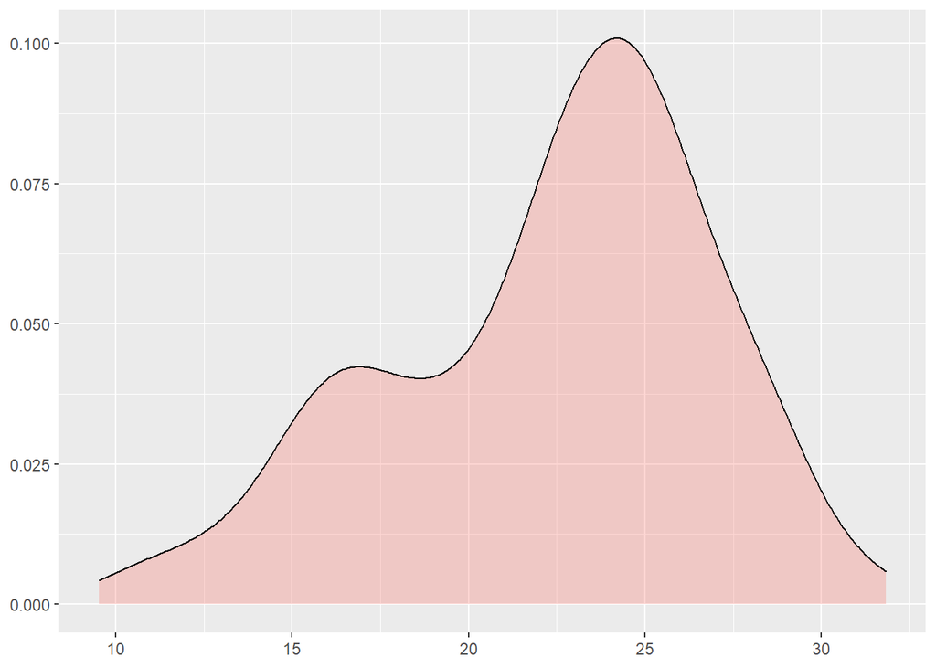

```r
data %>%
  filter(학교급 %in% c('중학교')) %>%
  mutate(학급당학생수 = 학생수_계_계 / 학급수_계) %>%
  ggplot(aes(x = 학급당학생수, fill = 학교급)) +
  geom_density(alpha = 0.3) +
  labs(x = '중학교', y = '') +
  theme(legend.position = 'none',
        axis.title.y=element_blank(),
        axis.title.x=element_blank())  -> density_중학교

density_중학교
```

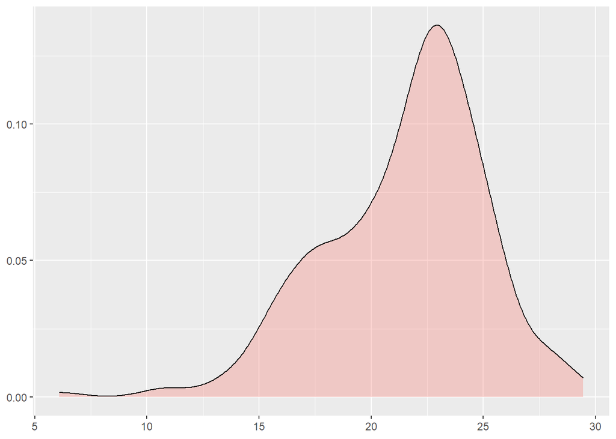

```r
data %>%
  filter(학교급 %in% c('고등학교')) %>%
  mutate(학급당학생수 = 학생수_계_계 / 학급수_계) %>%
  ggplot(aes(x = 학급당학생수, fill = 학교급)) +
  geom_density(alpha = 0.3) +
  labs(x = '고등학교', y = '') +
  theme(legend.position = 'none',
        axis.title.y=element_blank(),
        axis.title.x=element_blank())  -> density_고등학교

density_고등학교
```

## 학교급별 시도별 학급당 학생수 막대 플롯

학교급별 시도별 학생수 막대 플롯은 다음과 같이 생성한다.

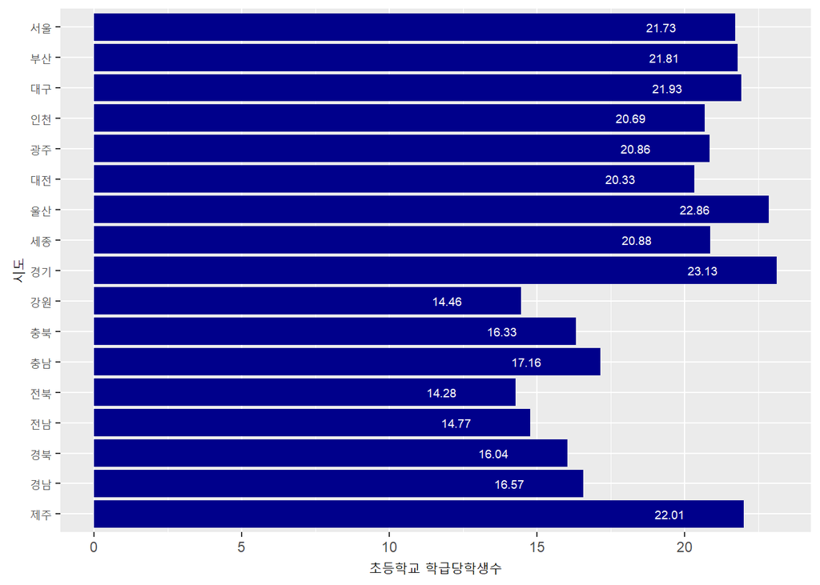

```r
data %>%
  filter(학교급 %in% c('초등학교')) %>%
  mutate(학급당학생수 = 학생수_계_계 / 학급수_계) %>%
  group_by(시도) %>%
  summarise(평균.학급당학생수 = mean(학급당학생수)) %>%
  ggplot(aes(x = 평균.학급당학생수, y = fct_relevel(시도, '서울', '부산', '대구', '인천', '광주', '대전', '울산', '세종', '경기', '강원', '충북', '충남', '전북', '전남', '경북', '경남', '제주'))) +
  geom_col(fill = 'dark blue') +
  geom_text(aes(label = round(평균.학급당학생수, 2), x = 평균.학급당학생수-2.5), color = 'white', size = 2.5) +
  labs(x = '초등학교 학급당학생수', y = '시도') +
  scale_y_discrete(limits=rev) -> bar_초등학교

bar_초등학교
```

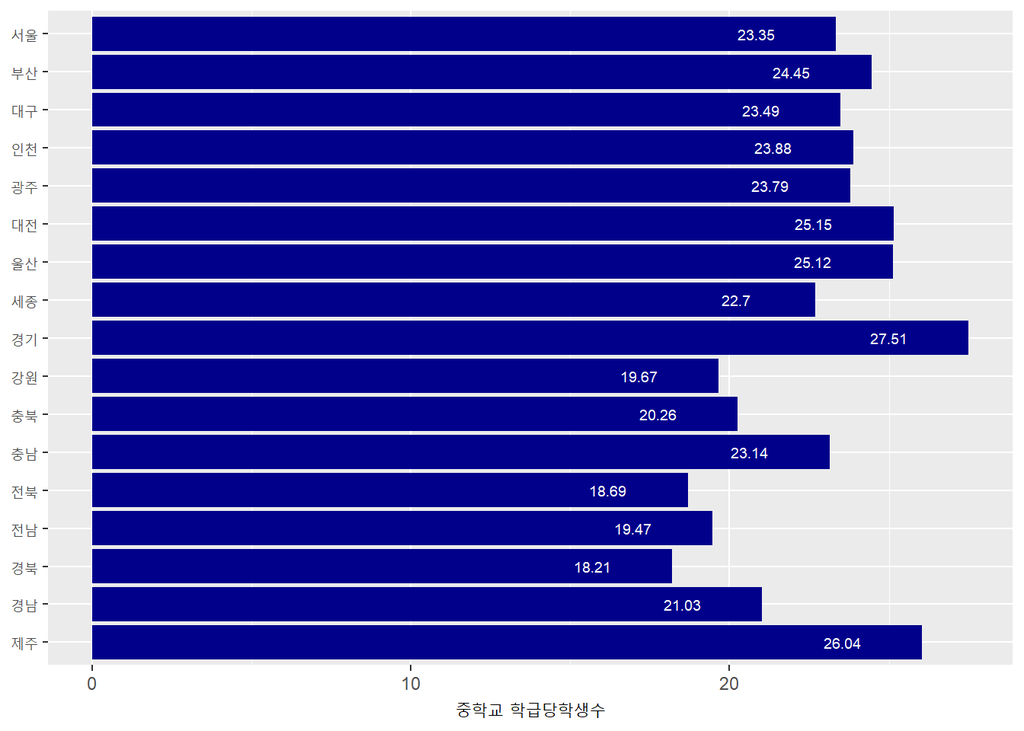

```r
data %>%
  filter(학교급 %in% c('중학교')) %>%
  mutate(학급당학생수 = 학생수_계_계 / 학급수_계) %>%
  group_by(시도) %>%
  summarise(평균.학급당학생수 = mean(학급당학생수)) %>%
  ggplot(aes(x = 평균.학급당학생수, y = fct_relevel(시도, '서울', '부산', '대구', '인천', '광주', '대전', '울산', '세종', '경기', '강원', '충북', '충남', '전북', '전남', '경북', '경남', '제주'))) +
  geom_col(fill = 'dark blue') +
  geom_text(aes(label = round(평균.학급당학생수, 2), x = 평균.학급당학생수-2.5), color = 'white', size = 2.5) +
  labs(x = '중학교 학급당학생수', y = '시도') +
  scale_y_discrete(limits=rev) +
  theme(axis.title.y=element_blank()) -> bar_중학교

bar_중학교
```

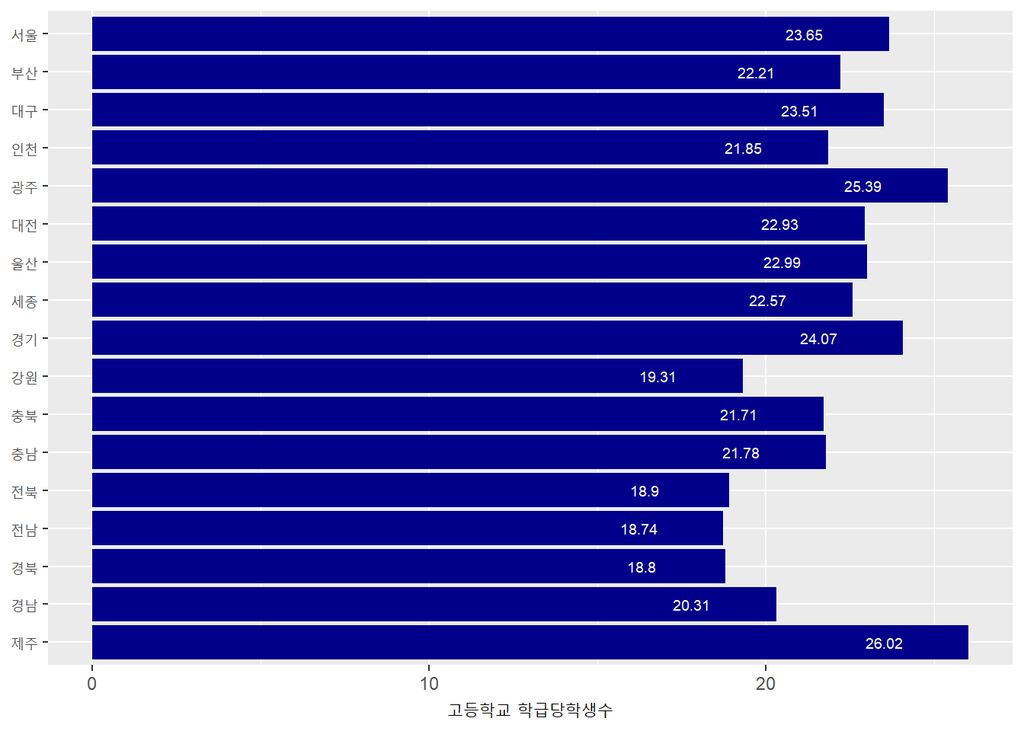

```r
data %>%
  filter(학교급 %in% c('고등학교')) %>%
  mutate(학급당학생수 = 학생수_계_계 / 학급수_계) %>%
  group_by(시도) %>%
  summarise(평균.학급당학생수 = mean(학급당학생수)) %>%
  ggplot(aes(x = 평균.학급당학생수, y = fct_relevel(시도, '서울', '부산', '대구', '인천', '광주', '대전', '울산', '세종', '경기', '강원', '충북', '충남', '전북', '전남', '경북', '경남', '제주'))) +
  geom_col(fill = 'dark blue') +
  geom_text(aes(label = round(평균.학급당학생수, 2), x = 평균.학급당학생수-2.5), color = 'white', size = 2.5) +
  labs(x = '고등학교 학급당학생수', y = '시도') +
  scale_y_discrete(limits=rev) +
  theme(axis.title.y=element_blank()) -> bar_고등학교

bar_고등학교
```

## `patchwork`를 사용하여 하나의 플롯으로 만들기

`patchwork`를 사용하여 여러 `ggplot`의 위치를 구성할 때에는 `+`, `/`, `|` 등의 연산자를 사용하면 쉽게 구성할 수 있다.

### `+`

`+` 연산자는 플롯들을 순서대로 오른쪽으로 붙여주는 역할을 한다. 아래의 코드는 세개의 밀도함수 플롯을 하나로 붙이는 코드이다.

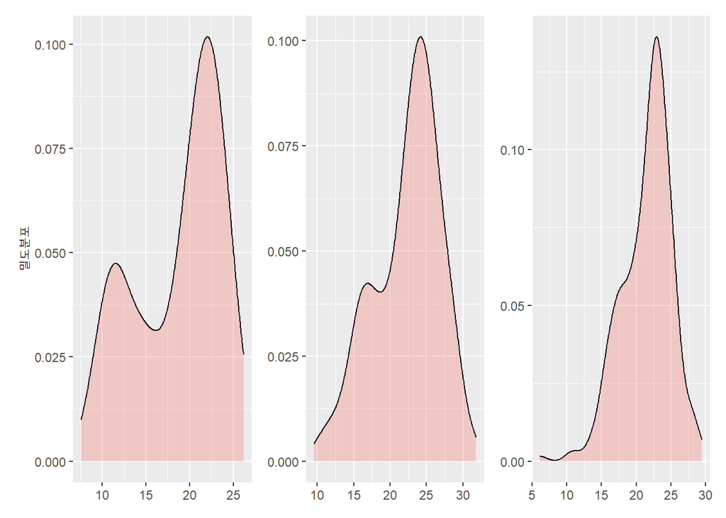

```r
density_초등학교 + density_중학교 + density_고등학교
```

### `/`

`/` 연산자는 플롯들을 순서대로 아래쪽으로 붙여주는 역할을 한다. 아래의 코드는 밀도함수 플롯 아래에 막대 플롯을 하나로 붙이는 코드이다.

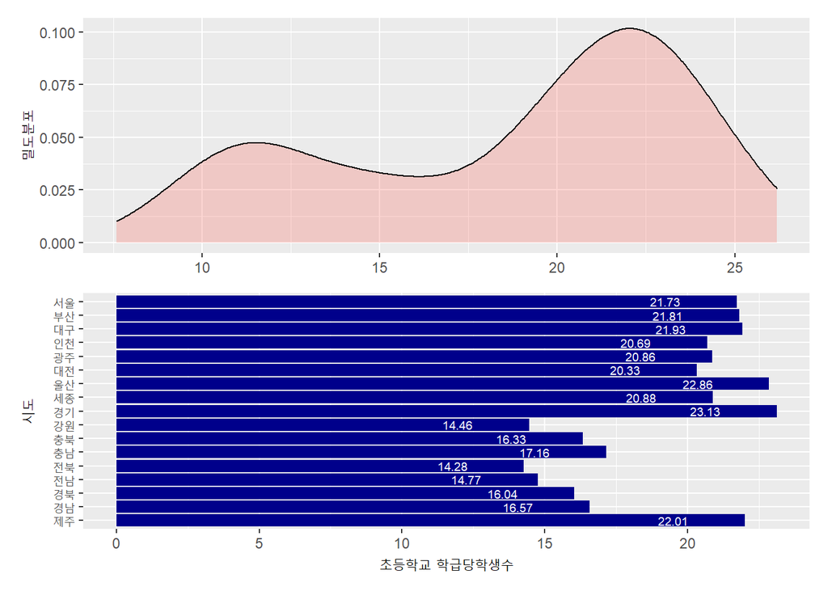

```r
density_초등학교 / bar_초등학교
```

앞서 생성한 6개의 플롯을 조합하여 생성한 플롯은 다음과 같다.

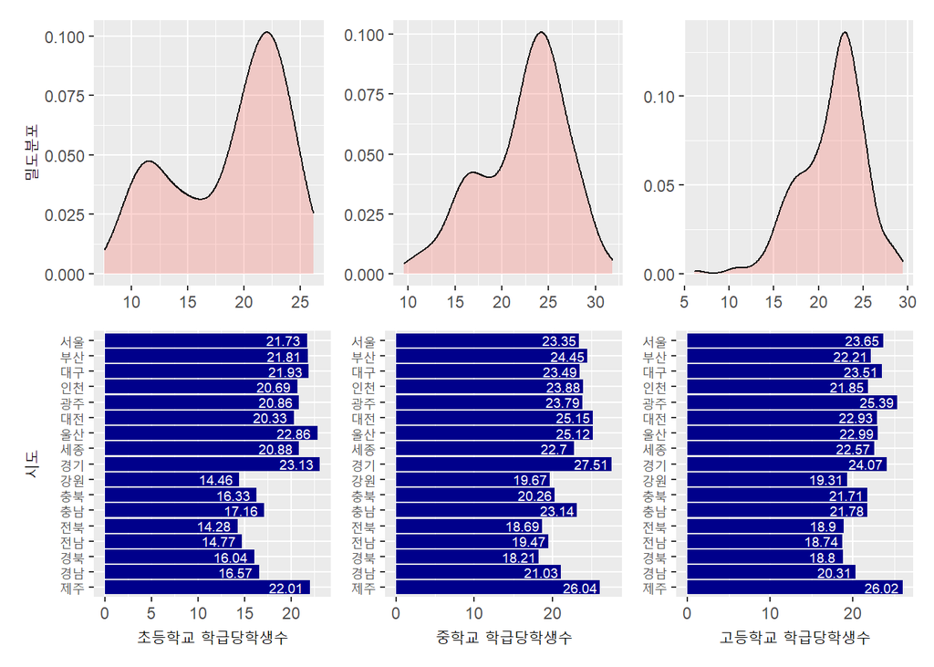

```r
((density_초등학교 + density_중학교 + density_고등학교) / (bar_초등학교 + bar_중학교 + bar_고등학교))
```

### 플롯 주석 붙이기

하나로 합쳐진 플롯에 대한 다양한 설명에 대한 주석을 붙이려면 `plot_annotation()`을 사용한다. `plot_annotation()`에서 설정할 수 있는 주석은 다음과 같다.

- `title` : 하나로 합쳐진 플롯에 대한 플롯 제목을 설정한다.
- `subtitle` : 하나로 합쳐진 플롯에 대한 플롯 부제목을 설정한다.
- `caption` : 하나로 합쳐진 플롯에 대한 플롯 캡션을 설정한다.
- `tag_levels` : 플롯들에 붙이는 번호를 설정한다. ‘a’, ‘A’, ‘1’, ‘i’, ’I’등의 번호를 붙일 수 있다.
- `tag_prefix`, `tag_surfix` : 플롯들에 붙이는 번호의 접두어나 접미어를 를 설정한다.
- `theme` : `ggplot`에서 사용하는 주석에 대한 `theme` 명세를 기술한다.

위에서 생성한 최종 플롯에 주석을 붙여 생성한 최종 플롯은 다음과 같다.

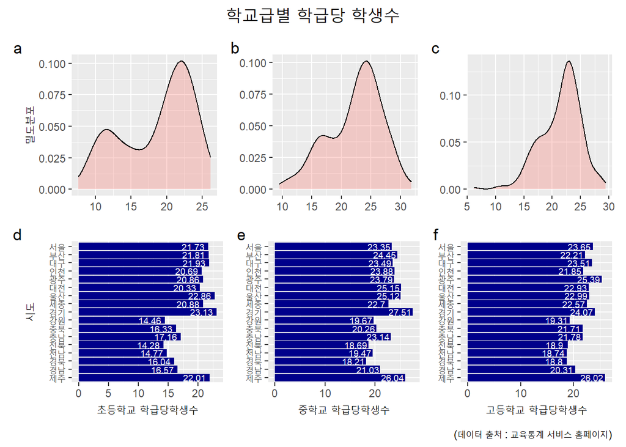

```r
((density_초등학교 + density_중학교 + density_고등학교) / (bar_초등학교 + bar_중학교 + bar_고등학교)) +
  plot_annotation(title = '학교급별 학급당 학생수',
                  tag_levels = 'a',
                  caption = '(데이터 출처 : 교육통계 서비스 홈페이지)',
                  theme = theme(plot.title = element_text(size = 16, hjust = 0.5)))
```